# DataAnalysis

23/Jan/2020

library(“dplyr”)

# Introduction

- Some functions not included in base rstudio will be required to perform the calculations
- Download “dplyr” and “ggplot2” using the following command:

```r
install.packages("dplyr")
instal.packages("ggplot2")
```

- Load “dplyr” and “ggplot2” into the the script to get access to the functions that will allow us to manipulate the data and create plots

```r
library("dplyr")
```

```r
library("ggplot2")
```

# Data Generation

### Loading our Data

- Assigning our data to an object in R

```r
MData<-read.csv("/Users/kevinsaroys/Desktop/Biol 432/assignment1/Measurements.csv")
print(MData)
```

```
##     X                   Species Limb.Length unitsL Limb.Width unitsW
## 1   1     Delphinapterus leucas    4.077746     cm 30.2476139     mm
## 2   2        Balaena mysticetus   19.811162     mm  2.9630575     mm
## 3   3 Nerodia sipedon insularum   15.324094     mm 19.6079238     mm
## 4   4         Phocoena phocoena    9.095439     cm 27.9048505     mm
## 5   5       Coregonus reighardi   11.564905     cm  0.6416516     mm
## 6   6          Moxostoma hubbsi    2.626883     cm 10.1763655     mm
## 7   7       Moxostoma duquesnei    7.986588     mm  6.1009137     cm
## 8   8     Coregonus nigripinnis   21.021766     mm  5.0916725     mm
## 9   9              Homo sapiens    9.832517     cm  0.4571765     cm
## 10 10           Panthera tigris   11.617886     cm  1.0378874     cm
```

# Data Manipulation

### Shortening column names

- To alter the original column names, a “dplyr” command use rename() function

```r
MData<-rename(MData,Spe=Species)
MData<-rename(MData,Lln=Limb.Length)
MData<-rename(MData,Lwd=Limb.Width)
MData<-rename(MData,unL=unitsL)
MData<-rename(MData,unW=unitsW)
```

- verify the name change function worked using names() functions

```r
names(MData)
```

```
## [1] "X"   "Spe" "Lln" "unL" "Lwd" "unW"
```

- Updated data set

```r
MData
```

```
##     X                       Spe       Lln unL        Lwd unW
## 1   1     Delphinapterus leucas  4.077746  cm 30.2476139  mm
## 2   2        Balaena mysticetus 19.811162  mm  2.9630575  mm
## 3   3 Nerodia sipedon insularum 15.324094  mm 19.6079238  mm
## 4   4         Phocoena phocoena  9.095439  cm 27.9048505  mm
## 5   5       Coregonus reighardi 11.564905  cm  0.6416516  mm
## 6   6          Moxostoma hubbsi  2.626883  cm 10.1763655  mm
## 7   7       Moxostoma duquesnei  7.986588  mm  6.1009137  cm
## 8   8     Coregonus nigripinnis 21.021766  mm  5.0916725  mm
## 9   9              Homo sapiens  9.832517  cm  0.4571765  cm
## 10 10           Panthera tigris 11.617886  cm  1.0378874  cm
```

```r
MData$unL<-c("cm")
MData$unW<-c("cm")
```

- Updated MData list with units changed

```r
print(MData)
```

```
##     X                       Spe       Lln unL        Lwd unW
## 1   1     Delphinapterus leucas  4.077746  cm 30.2476139  cm
## 2   2        Balaena mysticetus 19.811162  cm  2.9630575  cm
## 3   3 Nerodia sipedon insularum 15.324094  cm 19.6079238  cm
## 4   4         Phocoena phocoena  9.095439  cm 27.9048505  cm
## 5   5       Coregonus reighardi 11.564905  cm  0.6416516  cm
## 6   6          Moxostoma hubbsi  2.626883  cm 10.1763655  cm
## 7   7       Moxostoma duquesnei  7.986588  cm  6.1009137  cm
## 8   8     Coregonus nigripinnis 21.021766  cm  5.0916725  cm
## 9   9              Homo sapiens  9.832517  cm  0.4571765  cm
## 10 10           Panthera tigris 11.617886  cm  1.0378874  cm
```

### Creating the Volume column

```r
MData<-mutate(MData, Volume= Lln*Lwd)
MData
```

```
##     X                       Spe       Lln unL        Lwd unW     Volume
## 1   1     Delphinapterus leucas  4.077746  cm 30.2476139  cm 123.342095
## 2   2        Balaena mysticetus 19.811162  cm  2.9630575  cm  58.701610
## 3   3 Nerodia sipedon insularum 15.324094  cm 19.6079238  cm 300.473660
## 4   4         Phocoena phocoena  9.095439  cm 27.9048505  cm 253.806859
## 5   5       Coregonus reighardi 11.564905  cm  0.6416516  cm   7.420640
## 6   6          Moxostoma hubbsi  2.626883  cm 10.1763655  cm  26.732122
## 7   7       Moxostoma duquesnei  7.986588  cm  6.1009137  cm  48.725484
## 8   8     Coregonus nigripinnis 21.021766  cm  5.0916725  cm 107.035947
## 9   9              Homo sapiens  9.832517  cm  0.4571765  cm   4.495196
## 10 10           Panthera tigris 11.617886  cm  1.0378874  cm  12.058057
```

## Plotting our generated data

- Width and length will be plotted using the function qplot()

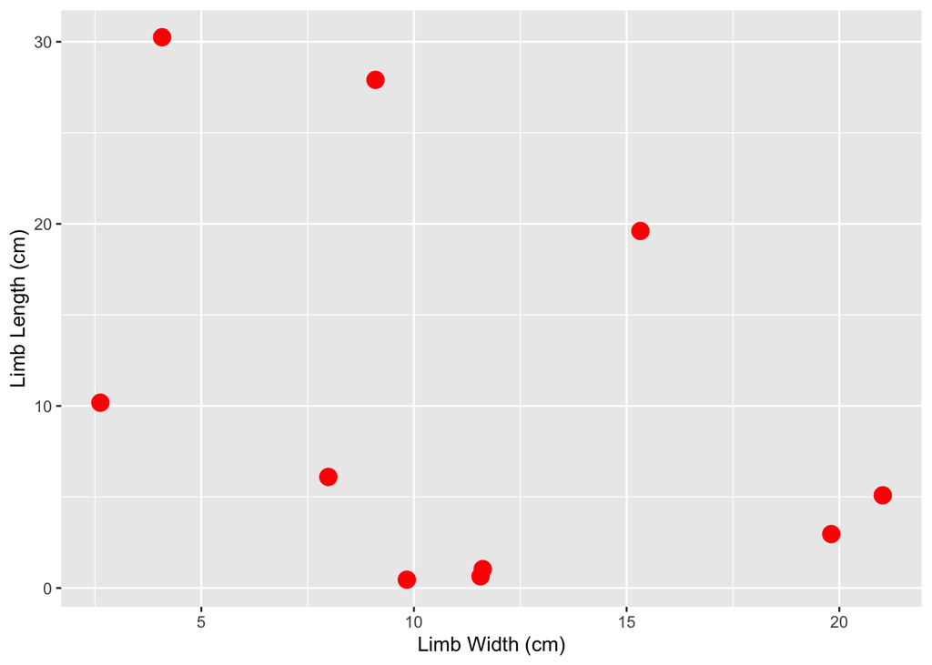

```r
Plot1<-qplot(data=MData,x=Lln,y=Lwd,ylab="Limb Length (cm)",xlab="Limb Width (cm)",size=I(4),color=I("red"))
print(Plot1)
```

- Next we will plot Width and Length for species that have above-average volume
- First we must calculate the average volume of the species which will be used to sort our data later

```r
mean(MData$Volume)
```

```
## [1] 94.27917
```

```r
MData %>%
  select(Spe,Lln,Lwd,Volume) %>%
  filter(Volume>=94.8)
```

```
##                         Spe       Lln       Lwd   Volume
## 1     Delphinapterus leucas  4.077746 30.247614 123.3421
## 2 Nerodia sipedon insularum 15.324094 19.607924 300.4737
## 3         Phocoena phocoena  9.095439 27.904851 253.8069
## 4     Coregonus nigripinnis 21.021766  5.091672 107.0359
```

- Plottting this data

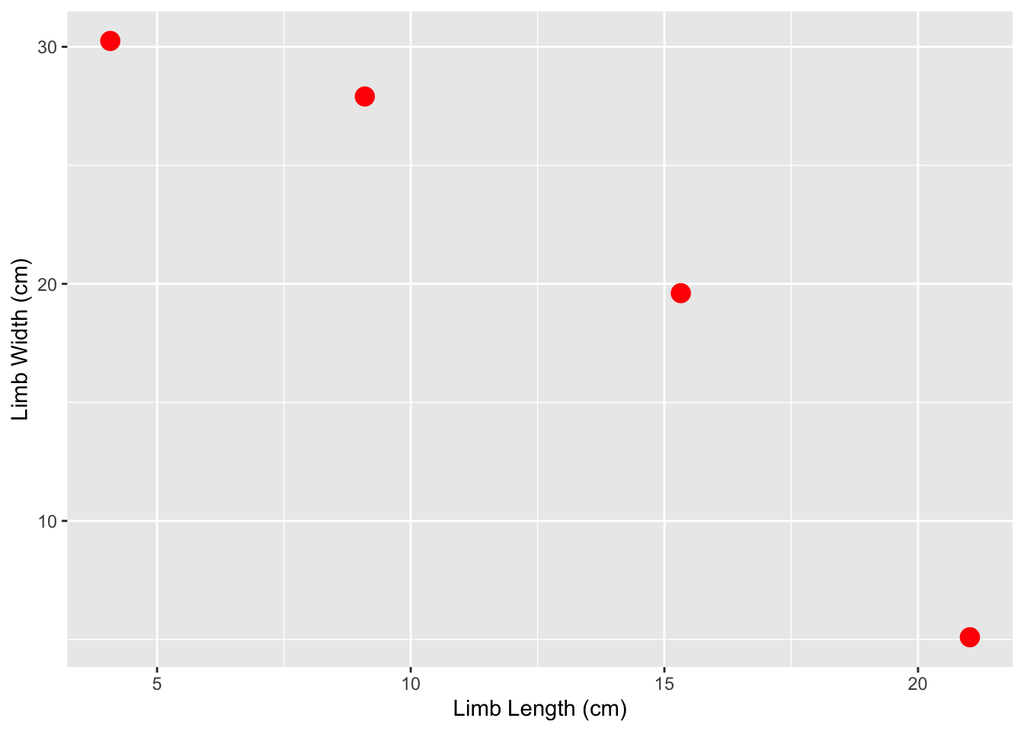

```r
Plot2<-MData %>%
  select(Spe,Lln,Lwd,Volume) %>%
  filter(Volume>=94.8)
qplot(data=Plot2,x=Lln,y=Lwd,xlab="Limb Length (cm)", ylab="Limb Width (cm)",color=I("red"),fill=I("blue"),size=I(4))
```

- Creating a table for species with below-average volume only

```r
Plot3<-MData %>%
  select(Spe,Volume) %>%
  filter(Volume<=94.8)
print(Plot3)
```

```
##                   Spe    Volume
## 1  Balaena mysticetus 58.701610
## 2 Coregonus reighardi  7.420640
## 3    Moxostoma hubbsi 26.732122
## 4 Moxostoma duquesnei 48.725484
## 5        Homo sapiens  4.495196
## 6     Panthera tigris 12.058057
```

- Now we must group the species into 2 seperate and arbitrary groups
- First grouping will be done based on taxon, each species will be assigned a 1 or 2 to group them into seperate taxons
- Second grouping will be done based on whether the animal can fly, will be grouped into YES or NO
- Then we will summarize the data using the summarize() function to find mean and standard deviation across the groups

```r
MData<-mutate(MData, Taxon=sample(x=c("One","Two"),prob=c(0.5,0.5),size=10,replace=TRUE))
MData<-mutate(MData, Flight=sample(x=c("YES","NO"),prob=c(0.5,0.5),size=10,replace=TRUE))
print(MData)
```

```
##     X                       Spe       Lln unL        Lwd unW     Volume Taxon
## 1   1     Delphinapterus leucas  4.077746  cm 30.2476139  cm 123.342095   One
## 2   2        Balaena mysticetus 19.811162  cm  2.9630575  cm  58.701610   Two
## 3   3 Nerodia sipedon insularum 15.324094  cm 19.6079238  cm 300.473660   Two
## 4   4         Phocoena phocoena  9.095439  cm 27.9048505  cm 253.806859   Two
## 5   5       Coregonus reighardi 11.564905  cm  0.6416516  cm   7.420640   Two
## 6   6          Moxostoma hubbsi  2.626883  cm 10.1763655  cm  26.732122   One
## 7   7       Moxostoma duquesnei  7.986588  cm  6.1009137  cm  48.725484   Two
## 8   8     Coregonus nigripinnis 21.021766  cm  5.0916725  cm 107.035947   Two
## 9   9              Homo sapiens  9.832517  cm  0.4571765  cm   4.495196   Two
## 10 10           Panthera tigris 11.617886  cm  1.0378874  cm  12.058057   One
##    Flight
## 1     YES
## 2     YES
## 3     YES
## 4     YES
## 5      NO
## 6      NO
## 7     YES
## 8     YES
## 9      NO
## 10    YES
```

## Generating Summary data for our data.frame

- Summarize the mean and SD of Length, Width and Volume for each of the groups, and present in table form.
- First group is Taxon, included are the summaries of mean and sd for Length, Width, and Volume

```r
MData %>%
  select(Spe,Lln,Lwd,Volume,Taxon) %>%
  filter(Taxon=="One") %>%
  summarize(MeanLln=mean(Lln),MeanLwd=mean(Lwd),MeanVOL=mean(Volume),SDLln=sd(Lln),SDLwd=sd(Lwd),SDVOL=sd(Volume))
```

```
##    MeanLln  MeanLwd  MeanVOL    SDLln    SDLwd    SDVOL
## 1 6.107505 13.82062 54.04409 4.826953 14.94197 60.46066
```

- The other group in Taxon will be see as:

```r
MData %>%
  select(Spe,Lln,Lwd,Volume,Taxon) %>%
  filter(Taxon=="Two") %>%
  summarize(MeanLln=mean(Lln),MeanLwd=mean(Lwd),MeanVOL=mean(Volume),SDLln=sd(Lln),SDLwd=sd(Lwd),SDVOL=sd(Volume))
```

```
##   MeanLln  MeanLwd  MeanVOL    SDLln    SDLwd    SDVOL
## 1 13.5195 8.966749 111.5228 5.271389 10.58993 119.0189
```

- Next, the summaries for the Flight group who are “YES”

```r
MData %>%
  select(Spe,Lln,Lwd,Volume,Flight) %>%
  filter(Flight=="YES") %>%
  summarize(MeanLln=mean(Lln),MeanLwd=mean(Lwd),MeanVOL=mean(Volume),SDLln=sd(Lln),SDLwd=sd(Lwd),SDVOL=sd(Volume))
```

```
##    MeanLln  MeanLwd  MeanVOL    SDLln    SDLwd    SDVOL
## 1 12.70495 13.27913 129.1634 6.290594 12.36073 108.4401
```

- Summaries for the Flight group who are “NO”

```r
MData %>%
  select(Spe,Lln,Lwd,Volume,Flight) %>%
  filter(Flight=="NO") %>%
  summarize(MeanLln=mean(Lln),MeanLwd=mean(Lwd),MeanVOL=mean(Volume),SDLln=sd(Lln),SDLwd=sd(Lwd),SDVOL=sd(Volume))
```

```
##    MeanLln  MeanLwd  MeanVOL    SDLln    SDLwd    SDVOL
## 1 8.008102 3.758398 12.88265 4.740087 5.558888 12.08286
```